# Seaborn을 이용하여 시각화를 진행해 보겠습니다. 먼저 폰트 이슈부터 해결 하겠습니다.

이어서 그래프도 바로 보겠습니다.

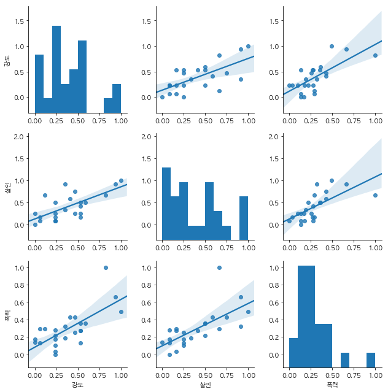

```python
import matplotlib.pyplot as plt
import seaborn as sns

%matplotlib inline

import platform
path = 'c:/Windows/Fonts/malgun.ttf'

from matplotlib import font_manager, rc

if platform.system() == 'Darwin':
    rc('font', family='AppleGothic')
elif platform.system() == 'Windows':
    font_name = font_manager.FontProperties(fname=path).get_name()
    rc('font', family=font_name)
else:
    print('Unknown system... sorry~~~~~')

# 강도, 살인, 폭력 건수에 대한 상관관계 시각화
sns.pairplot(crime_anal_norm, vars=["강도","살인","폭력"], kind='reg', size=3) # kind='reg'설정으로 상관관계 시각화하기
plt.show()
```

상관관계를 아주 손쉽게 시각화 해서 보여주고 있습니다. 잠시 분석을 해보면

- 강도 - 폭력
- 살인 - 폭력
- 강도 - 살인

전부다 **양의 상관 관계**를 갖는 다는 것이 확인 됩니다. 즉 예를 들어 **강도를 기준**으로 한다면 **폭력과 살인이 많이 일어난다**는 이야기가 됩니다.

다음은 CCTV와 살인, 강도에 대한 그래프를 확인 해보겠습니다.

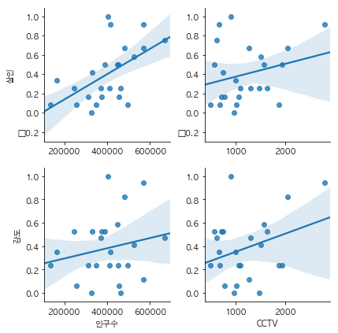

```python
sns.pairplot(crime_anal_norm, x_vars=["인구수","CCTV"], y_vars=["살인","강도"], kind='reg', size=3)
plt.show()
```

위의 시각화 데이터를 보면 분명히 인구수가 증가 할 수록 범죄가 증가하는 것이 확인 됩니다. 특히 살인은 매우 많이 일어나는 것이 확인 되네요  
또한 CCTV와 살인은 상관관계가 낮아 보입니다.( 그래프의 기울기 확인 ) 하지만 CCTV가 없을 때 살인사건이 많이 일어나는 것이 확인 됩니다.

다음은 인구수와 살인 및 폭력 검거율을 확인 해보겠습니다.

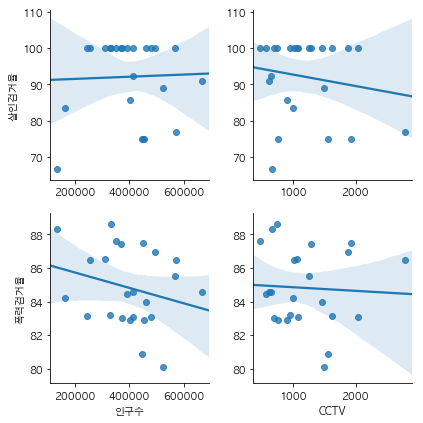

```python
sns.pairplot(crime_anal_norm, x_vars=["인구수","CCTV"], y_vars=["살인검거율","폭력검거율"], kind='reg', size=3)
plt.show()
```

이번 분석은 음의 상관관계를 의미합니다. 인구수가 많아질수록 폭력 검거율은 줄어들고, CCTV가 많아질수록 검거율도 낮아지네요??

다음은 heatmap을 이용해서 전체 검거율을 확인 해보겠습니다. 이 때 검거 항목 최고값을 100으로 한정 해 놓고 계산 하겠습니다

```python
tmp_max = crime_anal_norm['검거'].max() # 검거 최대값 가져오기
crime_anal_norm['검거'] = crime_anal_norm['검거'] / tmp_max * 100 #검거의 최대값을 100으로 설정하고 그에 맞는 검거율 구하기
crime_anal_norm_sort = crime_anal_norm.sort_values(by='검거', ascending=False) # 검거값으로 정렬
crime_anal_norm_sort.head()
```

| 구별 | 강간 | 강도 | 살인 | 절도 | 폭력 | 강간검거율 | 강도검거율 | 살인검거율 | 절도검거율 | 폭력검거율 | 인구수 | CCTV | 범죄 | 검거 |
| --- | --- | --- | --- | --- | --- | --- | --- | --- | --- | --- | --- | --- | --- | --- |
| 도봉구 | 0.000000 | 0.235294 | 0.083333 | 0.000000 | 0.000000 | 100.000000 | 100.0 | 100.0 | 44.967074 | 87.626093 | 348646.0 | 485 | 0.318627 | 100.000000 |
| 금천구 | 0.141210 | 0.058824 | 0.083333 | 0.172426 | 0.134074 | 80.794702 | 100.0 | 100.0 | 56.668794 | 86.465433 | 255082.0 | 1015 | 0.589867 | 97.997139 |
| 광진구 | 0.397695 | 0.529412 | 0.166667 | 0.671570 | 0.269094 | 91.666667 | 100.0 | 100.0 | 42.200925 | 83.047619 | 372164.0 | 707 | 2.034438 | 96.375820 |
| 동대문구 | 0.204611 | 0.470588 | 0.250000 | 0.314061 | 0.250887 | 84.393064 | 100.0 | 100.0 | 41.090358 | 87.401884 | 369496.0 | 1294 | 1.490147 | 95.444250 |
| 용산구 | 0.265130 | 0.529412 | 0.250000 | 0.169004 | 0.133128 | 89.175258 | 100.0 | 100.0 | 37.700706 | 83.121951 | 244203.0 | 1624 | 1.346674 | 94.776790 |

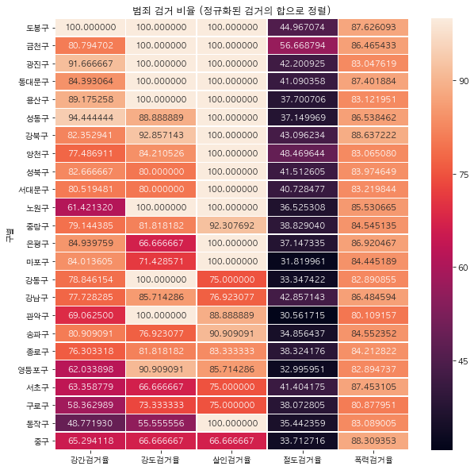

```python
target_col = ['강간검거율','강도검거율','살인검거율','절도검거율','폭력검거율']

#검거 비율로 정렬하기
crime_anal_norm_sort = crime_anal_norm.sort_values(by='검거', ascending=False)

plt.figure(figsize=(10,10))

#검거율을 heatmap에 표시하기 fmt : 숫자 format(f : float, d : digit(정수)))
sns.heatmap(crime_anal_norm_sort[target_col], annot=True, fmt='f', linewidths=.5)
plt.title('범죄 검거 비율 (정규화된 검거의 합으로 정렬)')
plt.show()
```

결과를 보니 절도 검거율은 다른 검거율에 비해서 매우 낮다고 볼 수 있겠습니다. 그래프의 하단으로 갈수록 검거율이 낮아지는데, 강남 3구 중 하나인 서초구가 보입니다  
검거율이 우수한 지역은 도봉구, 광진구, 성동구가 있네요.

이어서 정규화된 발생 건수로 확인 해 보겠습니다.

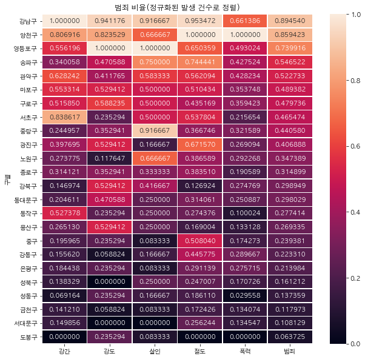

```python
target_col = ['강간','강도','살인','절도','폭력','범죄']

crime_anal_norm['범죄'] = crime_anal_norm['범죄'] / 5
crime_anal_norm_sort = crime_anal_norm.sort_values(by='범죄', ascending=False)
plt.figure(figsize=(10,10))
sns.heatmap(crime_anal_norm_sort[target_col], annot=True, fmt='f', linewidths=.5)
plt.title('범죄 비율(정규화된 발생 건수로 정렬)')
plt.show()
```

발생 건수로는 강남구, 양천구, 영등포구가 범죄 발생 건수가 높게 나타납니다. 그리고 송파구와 서초구도 높네요.